# HW4

# Problem 1

## Introduction

The topic of our project is to analyze user behavior on mobile phones. In this information age, constantly growing web users let entrepreneurs pay more and more attention to online business and user behavior analytics emerges as a popular field of study. Companies make great efforts in developing techniques on user behavior analytics and with a close scrutiny of online user behavior pattern, they are likely to considerably maximize their profits.

As the fast development of mobile phone, more and more powerful functions are integrated into it and inevitably, mobile phone gradually takes the place of laptop to become the most important media for people to access internet. As nowadays more online transactions are proceeded by mobile phones than by laptop, cell phones have become an ideal target for user behavior analysis.

That’s why we choose this topic. We’re intended to carry out researches on the phone type, operation system type, app store type, frequency of installing/removing app, as well as the factors contributing to all these user behavior, such as age, education, salary, nationality and etc.

Our data comes from https://dataverse.harvard.edu/dataset.xhtml?persistentId=doi:10.7910/DVN/27459

Dataset can be downloaded once you access the above website. It surveyed 10,208 people from more than 15 countries on their mobile app usage behavior.

# Problem 2

## Team Section

TeamName: GoLions

Minghong ZHENG (mz2597): clean data

Qiong HU (qh2174): write document

Then we’ll work together to analyze and plot data.

# Problem 3

## Data Description

The surveys were taken in 2012 online. All the survey samples are confirmed to be generated randomly to be considered as a representative sample. There are 30 questions in the survey data used for mobile app user behavior analysis. We will analyze four important features (i.e. mobile devices that people used, Appstores that they used, Countries that they live in, their age) to see the individual variable distributions.

## Clean the data

### Missing values

We found there are a lot of missing data in four features. Replacing all of them with mode or media will mislead our results. Therefore, we decided to keep the missing values first and drop them when it is necessary. For example, when we need to analyze the four features individually, we only need to drop the missing values in each feature individually rather than drop all the rows as long as there exists at least a missing value in one of the four features in a row, which will lose a lot of useful information.

```r
library(ggplot2)
library(vcdExtra)
library(plyr)
library(readxl)
library(gridExtra)
library(extracat)
#load the data
data=read.csv( "/Users/MinghongZheng/Documents/data_visulization/project/mobile_app_user_dataset_2.csv",
header=TRUE,sep=",")

#excluding unnecessary dataset
myvars <- names(data) %in% c("ID", "StartDate", "EndDate","Response.Status","Participant.Type","Q1_2_TEXT","Q1_3_TEXT","Q1_4_TEXT","Q1_5_TEXT","Q1_6_TEXT","Q1_7_TEXT","Q12.1_1_TEXT","Q12.1_2_TEXT","Q12.1_3_TEXT","Q12.1_4_TEXT","Q12.2")

#drop the first row
newdata <- data[!myvars][-1,]
"repalce all empty cell as missing values"
```

```
[1] "repalce all empty cell as missing values"
```

```
repalce all empty cell as missing values
```

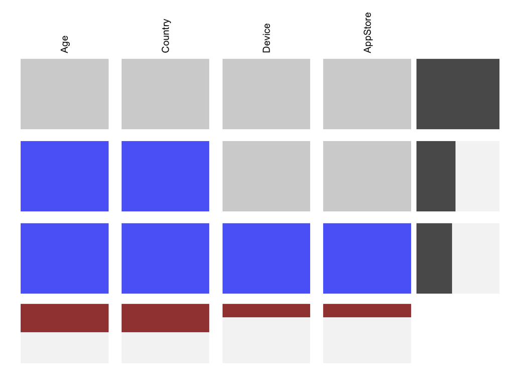

```r
newdata[newdata==""]=NA
#plot the missing values
myvars1=names(newdata) %in% c("Q3_1_TEXT","Q4","Q17","Q19")
table4=newdata[myvars1]
colnames(table4)=c("Device","AppStore","Age","Country")
visna(table4, sort="b")
```

### Clean Device Feature

Since it is a survey data, a lot of people made typos for their answers. For example, many people wrote Samsung as samaung ,samgung, Samgung and so on. Therefore, we need to clean those typos.

```r
table=count(newdata, 'Q3_1_TEXT')
table1 <- table[order(-table$freq),]
#repalce the empty cells as NA
#create a table only with Q3_1_TEXT column
col=newdata$Q3_1_TEXT
#replace the missing values with NA
col[col==""]=NA
#replace the invalid words as Samsung
levels(col)[c(22,401,405:464,486:490,551:555,175:177,404)]="Samsung"
table=count(col)
table1=table[order(-table$freq),]

#replace the invalid words as iphone
levels(col)[c(21,49:70,209:214,220:235)]="apple"#include iphone and ipad
table=count(col)
table1=table[order(-table$freq),]

#replace the invalid words as Nokia
levels(col)[c(275,277:286,289:298)]="nokia"
table=count(col)
table1=table[order(-table$freq),]


#replace the invalid words as LG
levels(col)[c(216:217,221:232)]="LG"
table=count(col)
table1=table[order(-table$freq),]

#replace the invalid words as HTC
levels(col)[c(162,164,170:175,177:179)]="HTC"
table=count(col)
table1=table[order(-table$freq),]

#replace the invalid words as Blackberry
levels(col)[c(65:66,71:93)]="Blackberry"
table=count(col)
table1=table[order(-table$freq),]

#replace the invalid words as Sony
levels(col)[c(315:325,329:364,107,108)]="Sony"
table=count(col)
table1=table[order(-table$freq),]

#replace the invalid words as Motorola
levels(col)[c(26,196:212)]="Motorola"
table=count(col)
table1=table[order(-table$freq),]

#replace the invalid words as Huawei
levels(col)[c(145:149)]="Huawei"
table=count(col)
table1=table[order(-table$freq),]

#replace the invalid words as NA
levels(col)[c(1:20,23:24,27:37,146:147,154:156)]=NA
table=count(col)
table1=table[order(-table$freq),]

#set else as others
levels(col)[c(-1,-2,-4,-32,-74,-104,-139,-168)]='others'
table=count(col)
table1=table[order(-table$freq),]

#copy the col back to newdata
newdata$Q3_1_TEXT=col

percent=nrow(subset(newdata,Q3_1_TEXT %in% c("Samsung","apple","nokia")))/nrow(newdata[!is.na(newdata$Q3_1_TEXT),])
```

### Clean Age Feature

treat invalid context as NA

```r
age=newdata$Q17
age[age==""]=NA
age[age=="What is your age?-1=Male, 2=Female"]=NA
age1=as.numeric(as.character(age))
newdata$Q17=age1
```

### Clean Country Feature

treat invalid context as NA

```r
country=newdata$Q19
country[country==""]=NA
levels(country)[2:17]=c("USA","Japan","Mexico","Russia","South Korea","Spain","Others","Australia","Brazil","UK","Canada","China","France","Germany","India")
newdata$Q19=country
```

### Clean Appstore Feature

treat invalid context as NA

```r
appstore=newdata$Q4
appstore[appstore==""]=NA
levels(appstore)[2:11]=c("Apple","Don't Use","Blackberry","Google Play/Android","Nokia","Samsung","Windows Phone","cannot run apps","don't know","others")
newdata$Q4=appstore
```

### Plot Individual Variables and Data Analysis for Four Features

Plot histogram graph for age and barchart for Appstore, mobile device, and country.

As you can see below

-AppStore:

Google Play/Android, cannot run apps, apple, nokia dominate the variable AppStore. It makes sense that a majority of people used Google Play/Android, apple and nokia since most of people’s devices are Google Play/Android, apple and nokia. We were suprised to see a lot of people cannot use apps. I guess since this data is from 2012, some phones did not support app features. Also maybe some people who do not know how to use an app mistakenly choose this choice.

-Device:

Samsung, nokia, and apple dominate the variable mobile device, which are 60% out of overall.

-Country:

-Age:

The distribution of age is skewed to the right. It indicates that younger people tended to be more willing to take the survey and use mobile device.

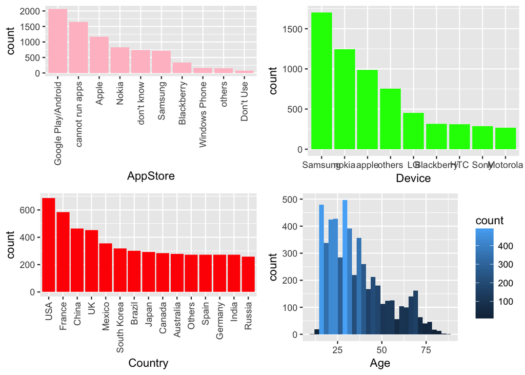

```r
#make barchart shown in order
reorder_size <- function(x) {
  factor(x, levels = names(sort(table(x),decreasing = TRUE)))
}
#histogram and barchart
cs <- ggplot(newdata[!is.na(newdata$Q4),],aes(reorder_size(Q4))) + geom_bar(fill="pink")+xlab("AppStore")+
  theme(axis.text.x=element_text(angle=90,hjust=1,vjust=0.5))
sx <- ggplot(newdata[!is.na(newdata$Q3_1_TEXT),],aes(reorder_size(Q3_1_TEXT))) + geom_bar(fill="green")+xlab("Device")
ag <- ggplot(newdata[!is.na(newdata$Q19),],aes(reorder_size(Q19))) +geom_bar(fill="red")+xlab("Country")+
  theme(axis.text.x=element_text(angle=90,hjust=1,vjust=0.5))
su <- ggplot(newdata[!is.na(newdata$Q17),],aes(Q17)) + geom_histogram(aes(fill = ..count..))+xlab("Age")
grid.arrange(cs, sx, ag, su, ncol=2)
```

#### Boxplot for Age

As you can see from both summary and boxplot, most people who take the survey from 23 to 46 years old. It shows that more young and middle-aged people tended to use mobile apps, which makes senses since they are better at new techonolgy compared to old peope and kids.

```r
summary(newdata$Q17)
```

```
   Min. 1st Qu.  Median    Mean 3rd Qu.    Max.    NA's
  11.00   23.00   32.00   36.17   46.00   88.00    4842
```

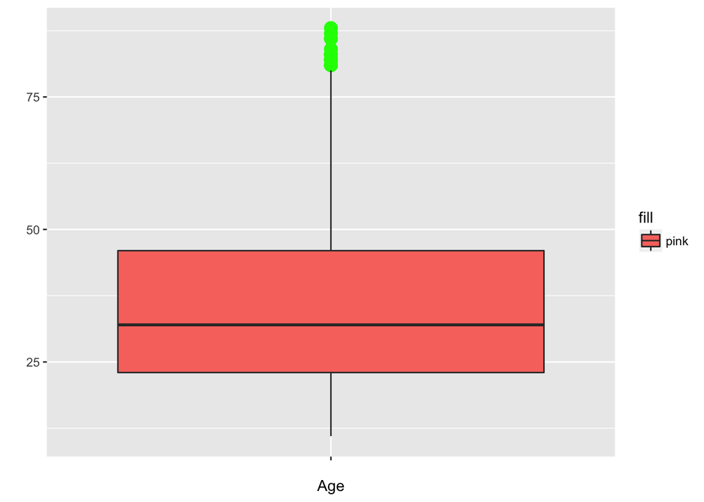

```r
ggplot(newdata, aes(x=" ", Q17,fill="pink")) + geom_boxplot(outlier.colour ="green",outlier.size = 4)+xlab("Age")+ylab("")
```

#### Relationship bteween Country and Device

This graph shows relationship between device and country. We choose the three largest brands - Apple, Samsung, Nokia, and eight countries with most survey participants, that’s USA, France, China, UK, Mexico, South Korea, Brazil, Japan.

As we can see, although Mexico ranks five regarding participants, it only has a small population using Apple, Samsung, Nokia. Generally, these three brands are popular in advanced countries.

Apple enjoys a good fame in foreign countries. There’re a large proportion of Apple users in China and France, probably because the lack of local mobile phone brands in those two countries.

As a most famous South Korean brand, Samsung is undoubtedly widely used in South Korea. Nokia has a nearly equal division, with comparably more users in USA, Japan and UK.

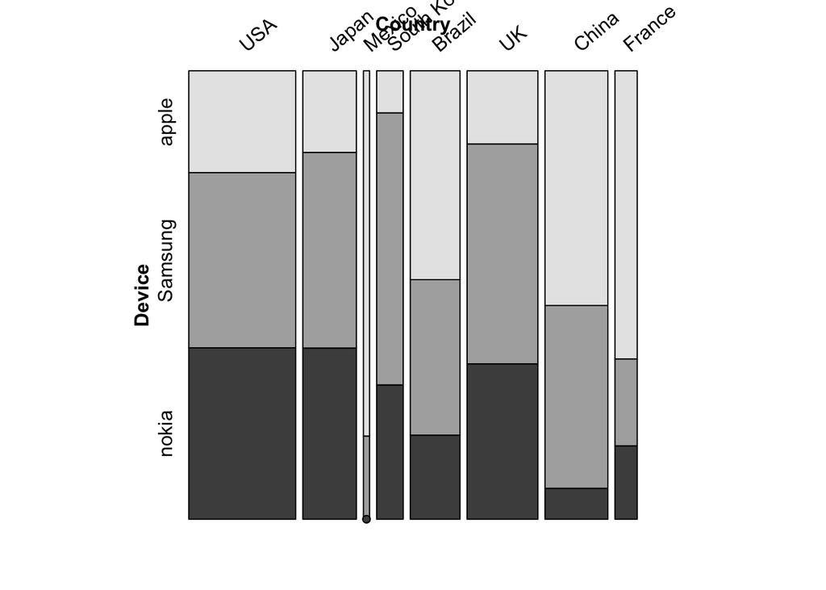

```r
#relationship bteween country vs device
newdata1=subset(newdata,Q3_1_TEXT %in% c("Samsung","apple","nokia"))
newdata2=newdata1[!is.na(newdata1$Q3_1_TEXT),]
newdata2=subset(newdata2,Q19 %in% c("USA","France","China","UK","Mexico","South Korea","Brazil","Japan"))
colnames(newdata2)[3]="Device"
colnames(newdata2)[113]="Country"
newdata2$Device=factor(newdata2$Device)
newdata2$Country=factor(newdata2$Country)

mosaic(Device~Country, data = newdata2, direction = c("v","h"),shade = T,labeling= labeling_border(rot_labels = c(40,0,0,90),
                                 just_labels = c("left",
                                                 "center",
                                                 "center",
                                                 "center")))
```

Most of devices except apple install android system, that’s why the Google Play/Android app store has most users.

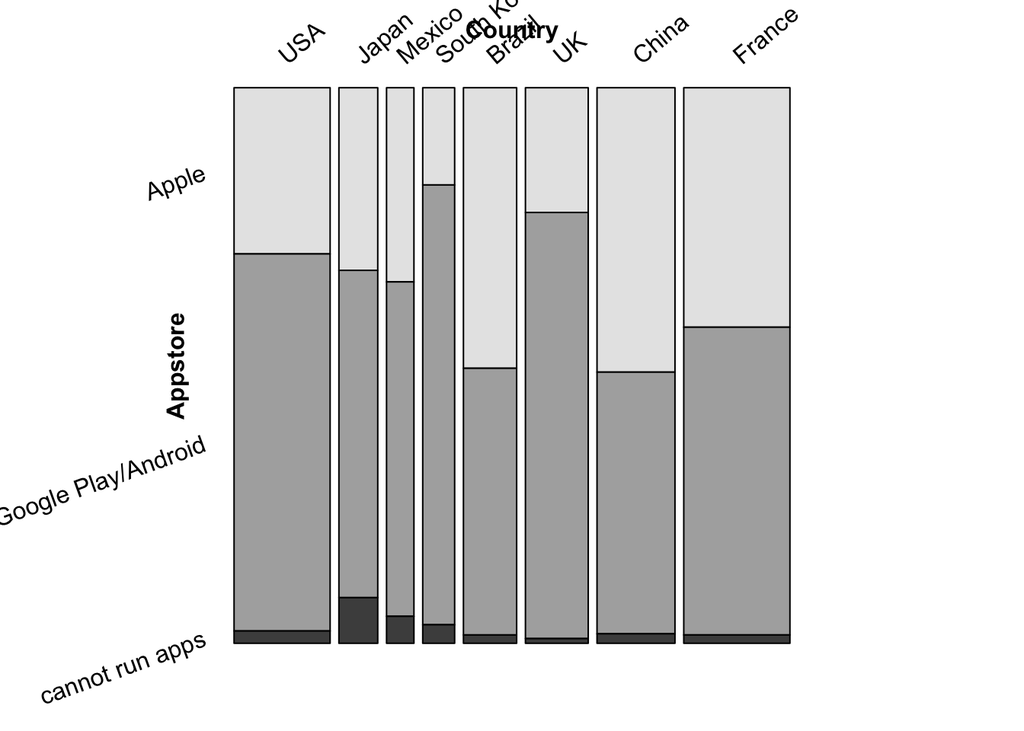

```r
#relationship bteween appstore vs device
newdata1=subset(newdata,Q4 %in% c("Google Play/Android","cannot run apps","Apple"))
newdata2=newdata1[!is.na(newdata1$Q4),]
newdata2=subset(newdata2,Q19 %in% c("USA","France","China","UK","Mexico","South Korea","Brazil","Japan"))
colnames(newdata2)[6]="Appstore"
colnames(newdata2)[113]="Country"
newdata2$Appstore=factor(newdata2$Appstore)
newdata2$Country=factor(newdata2$Country)

mosaic(Appstore~Country, data = newdata2, direction = c("v","h"),shade = T,labeling= labeling_border(rot_labels = c(40,0,0,20),
                                 just_labels = c("left",
                                                 "center",
                                                 "center",
                                                 "right")))
```